# Simple Illustration of Cluster Analysis

## Cluster Analysis

is a class of techniques used to classify objects or cases into relatively homogeneous groups called clusters. Objects in each cluster tend to be similar to each other and dissimilar to objects in the other clusters.

## Illustration

What follows is an illustration of three clustering algorithms: *hierarchical*, *k-means*, and *model-based clustering*.

## Create data

```r
library(ggplot2)
set.seed(1031)
data = data.frame(x1=sample(1:10,10,replace = T),
                  x2=sample(1:10,10,replace = T))
rownames(data) = 1:10
data
```

```
##    x1 x2
## 1   8 10
## 2   9  1
## 3   1  1
## 4   9  8
## 5   7  3
## 6   3  7
## 7   8  3
## 8   1  8
## 9   1  3
## 10  7  4
```

Scatter Plot

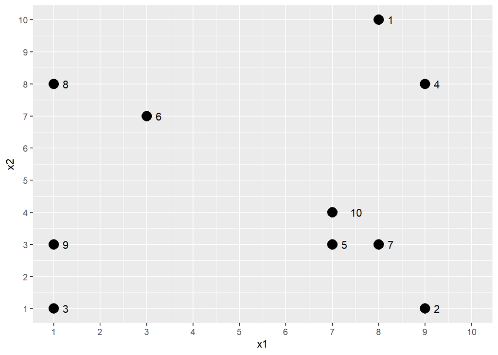

```r
ggplot(data=data,aes(x=x1,y=x2))+
  geom_point(aes(size=1.2))+
  scale_x_continuous(limits=c(1,10),breaks=1:10)+
  scale_y_continuous(limits=c(1,10),breaks=1:10)+
  guides(size=F)+
  geom_text(aes(label=rownames(data)),hjust=-1.5,vjust=0.5)
```

## Hierarchical Clustering

Compute distances

```r
distances = round(dist(data,method = "euclidean"),2)
distances
```

```
##        1     2     3     4     5     6     7     8     9
## 2   9.06
## 3  11.40  8.00
## 4   2.24  7.00 10.63
## 5   7.07  2.83  6.32  5.39
## 6   5.83  8.49  6.32  6.08  5.66
## 7   7.00  2.24  7.28  5.10  1.00  6.40
## 8   7.28 10.63  7.00  8.00  7.81  2.24  8.60
## 9   9.90  8.25  2.00  9.43  6.00  4.47  7.00  5.00
## 10  6.08  3.61  6.71  4.47  1.00  5.00  1.41  7.21  6.08
```

Cluster data based on distances

```r
clust = hclust(distances,method = "ward.D2")
```

Dendrogram: Tree presentation of cluster results

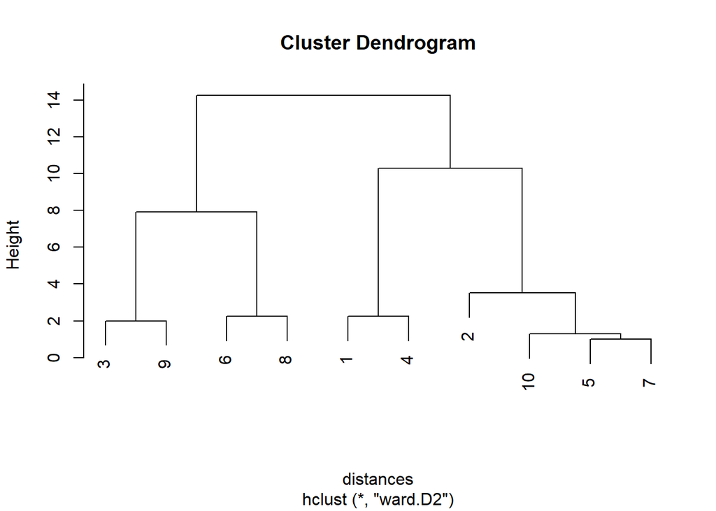

```r
plot(clust)
```

Number of Clusters  
Unlike predictive modeling techniques, clusters anlayses do not yield a unique solution. The number of clusters chosen is based on, (a) Distance: Clusters should be far apart relative to within cluster distances (b) Meaningfulness: Clusters should be meaningful within the domain of inquiry.  
Trying out a 2-cluster solution

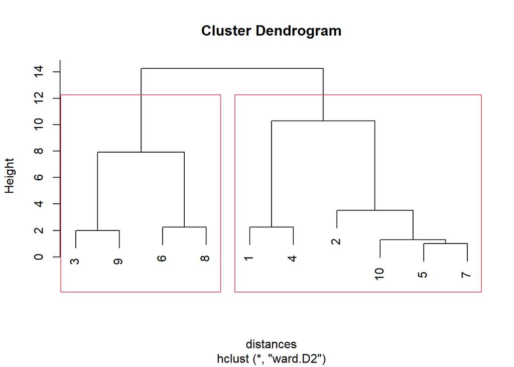

```r
plot(clust)
rect.hclust(tree=clust,k = 2)
```

Coloring the clusters in the Dendrogram. The library dendextend can be used to color clusters in the dendrogram

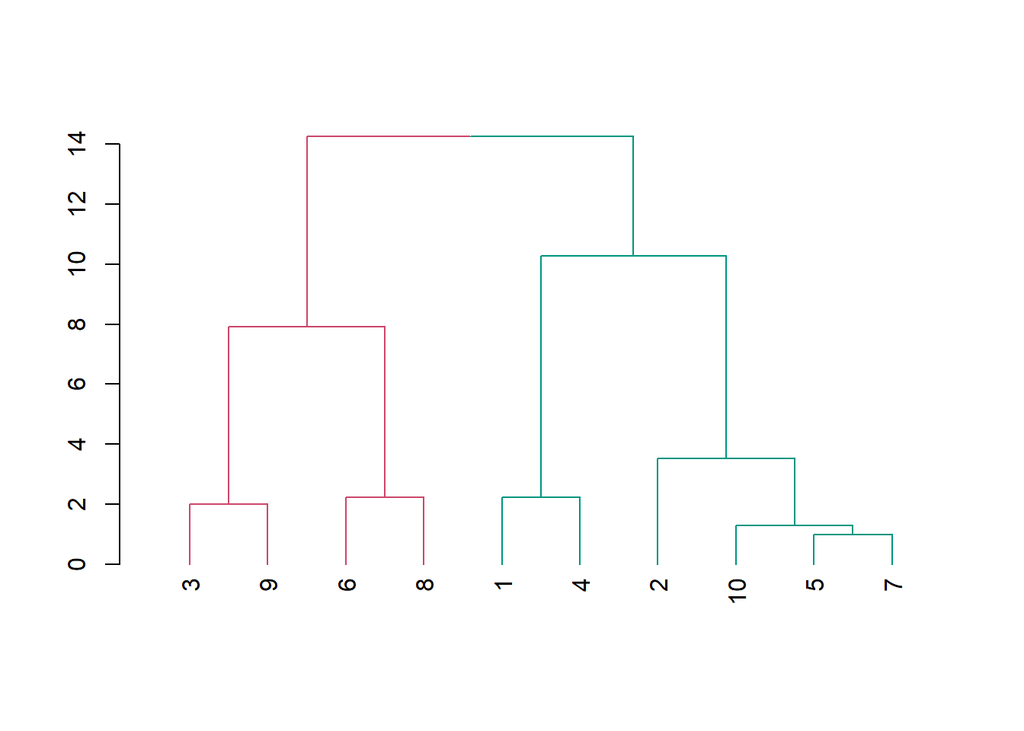

```r
library(dendextend)
plot(color_branches(as.dendrogram(clust),k=2))
```

Now, let us cut the data at two clusters. All clustering algorithms are similar in that they yield a fairly boring vector of cluster memberships.

```r
clusters = cutree(clust,k = 2)
clusters
```

```
##  1  2  3  4  5  6  7  8  9 10
##  1  1  2  1  1  2  1  2  2  1
```

This cluster membership can be highlighted in the original dendrogram

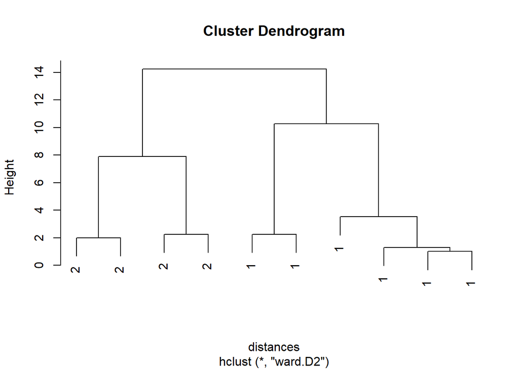

```r
plot(clust,label=clusters)
```

It is also possible to cut based on height

```r
clust$height
```

```
## [1]  1.000000  1.287918  2.000000  2.240000  2.240000  3.516336  7.902712
## [8] 10.279743 14.240875
```

Let us visualize the a plot of Clusters

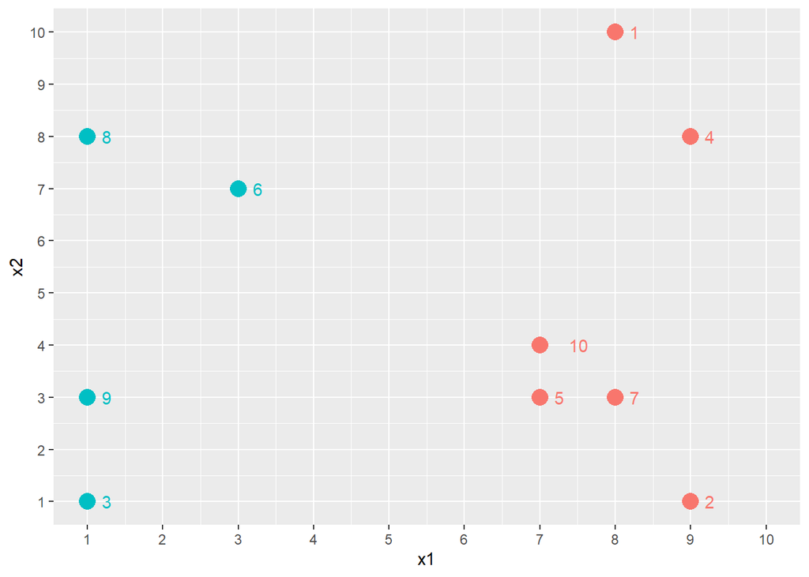

```r
data2 = cbind(data,clusters)
ggplot(data=data2,aes(x=x1,y=x2,color=factor(clusters)))+
  geom_point(aes(size=1.2))+
  scale_x_continuous(limits=c(1,10),breaks=1:10)+
  scale_y_continuous(limits=c(1,10),breaks=1:10)+
  guides(size=F,color=F)+
  geom_text(aes(label=rownames(data2)),hjust=-1.5,vjust=0.5)
```

Now, let us try out a 4-cluster solution

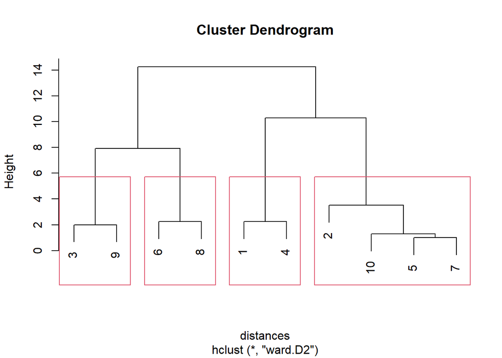

```r
plot(clust)
rect.hclust(tree=clust,k = 4)
```

Coloring the clusters in the Dendrogram

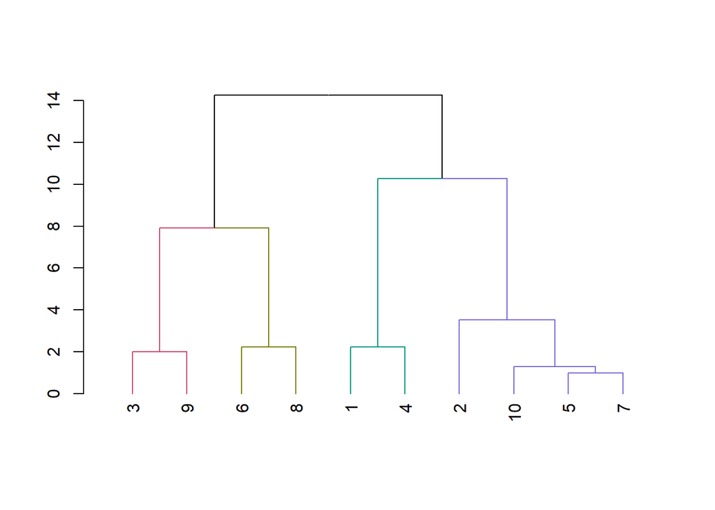

```r
library(dendextend)
plot(color_branches(as.dendrogram(clust),k=4))
```

Cut the data at 4 clusters

```r
clusters = cutree(clust,k = 4)
clusters
```

```
##  1  2  3  4  5  6  7  8  9 10
##  1  2  3  1  2  4  2  4  3  2
```

Let us visualize the a plot of a 4-Cluster Solution

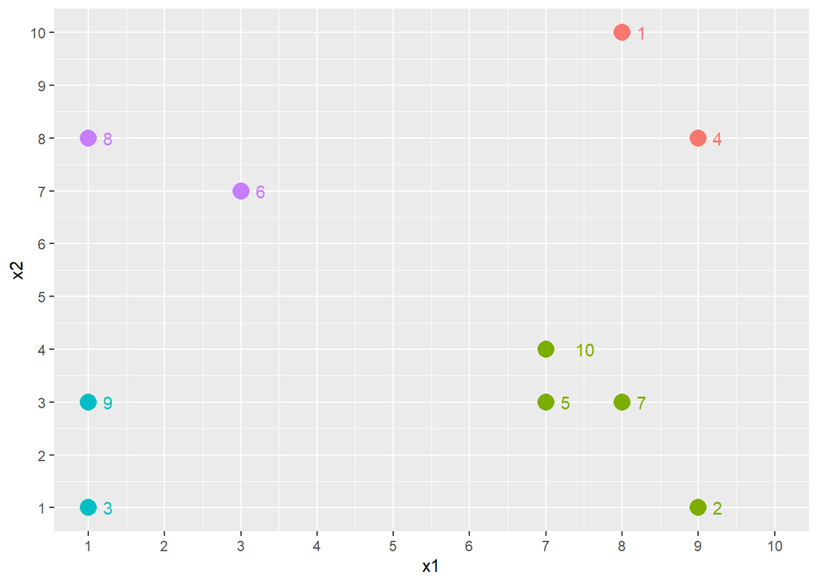

```r
data2 = cbind(data,clusters)
ggplot(data=data2,aes(x=x1,y=x2,color=factor(clusters)))+
  geom_point(aes(size=1.2))+
  scale_x_continuous(limits=c(1,10),breaks=1:10)+
  scale_y_continuous(limits=c(1,10),breaks=1:10)+
  guides(size=F,color=F)+
  geom_text(aes(label=rownames(data2)),hjust=-1.5,vjust=0.5)
```

## K-Means Clustering

Hierarchical clustering requires computing distances between every pair of observations. For large datasets, this can be a very expensive process, (for n observations have n(n-1)/2 distances). K-means clustering begins by arbitrarily placing centroids in the data and then iterating from that point to the final solution. This disorganized approach to clustering produces similar quality of clusters to hierarchical clustering but much faster.

It is worth noting that K-Means is sensitive to starting point, so the seed can influence final solution. Also, for k-means, one has to provide the number of centers.

```r
set.seed(100)
km = kmeans(data, centers = 4,iter.max = 1000)
```

A good cluster solution maximizes between cluster distance related to within cluster distances. The kmeans object generates this ratio which is useful in evaluating the suitability of cluster solution.

```r
km
```

```
## K-means clustering with 4 clusters of sizes 2, 4, 2, 2
##
## Cluster means:
##     x1   x2
## 1 8.50 9.00
## 2 7.75 2.75
## 3 2.00 7.50
## 4 1.00 2.00
##
## Clustering vector:
##  1  2  3  4  5  6  7  8  9 10
##  1  2  4  1  2  3  2  3  4  2
##
## Within cluster sum of squares by cluster:
## [1] 2.5 7.5 2.5 2.0
##  (between_SS / total_SS =  92.8 %)
##
## Available components:
##
## [1] "cluster"      "centers"      "totss"        "withinss"     "tot.withinss"
## [6] "betweenss"    "size"         "iter"         "ifault"
```

In fact, this ratio can be used to generate a scree plot. A sudden change in ratio marks the optimal cluster scheme.

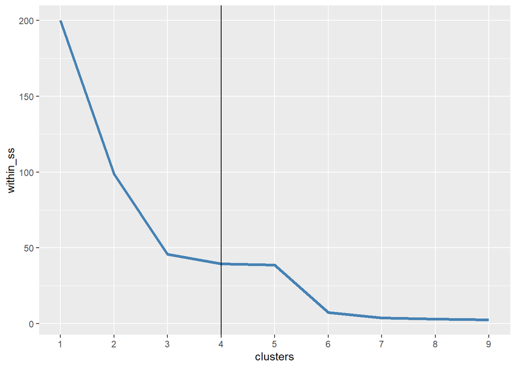

```r
within_ss = sapply(X = 1:9,
                   FUN = function(x) kmeans(data,centers = x,iter.max = 100)$tot.withinss)

ratio_ss = sapply(X = 1:9,
                  FUN = function(x) {
  km = kmeans(data,centers = x,iter.max = 100)
  ratio = km$betweenss/km$totss
  return(ratio)
})
dat = data.frame(clusters=1:9,within_ss, ratio_ss)

# Elbow in Within_ss
library(ggplot2)
ggplot(dat,aes(x=clusters,y=within_ss))+
  geom_line(color='steelblue',size=1.4)+
  scale_x_continuous(breaks=1:9,minor_breaks = 1:9)+
  geom_vline(xintercept=4)
```

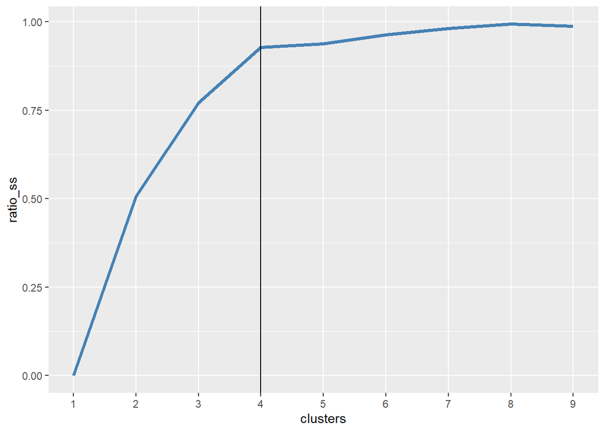

```r
# Elbow in Ratio
ggplot(dat,aes(x=clusters,y=ratio_ss))+
  geom_line(color='steelblue',size=1.4)+
  scale_x_continuous(breaks=1:9,minor_breaks = 1:9)+
  geom_vline(xintercept=4)
```

Another method used for determining the optimal number of cluster is the Silhoette method. Here we use the pam function to determine the average silhoeuette width. Note, pam runs an algorithm like k-means but not exactly the same as k-means. Since we are only using it to determine ideal number of cluster, it should be okay.

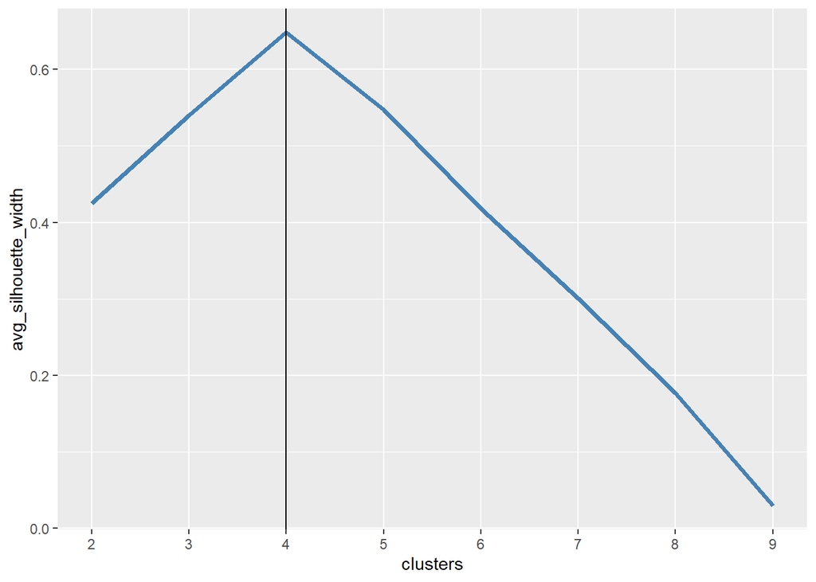

```r
library(cluster)
sil = sapply(2:9,FUN=function(x){
  pam(data,k=x)$silinfo$avg.width
})

ggplot(data.frame(clusters=2:9,avg_silhouette_width = sil),aes(x=clusters,y=avg_silhouette_width))+
  geom_line(color='steelblue',size=1.4)+
  scale_x_continuous(breaks=1:9,minor_breaks = 1:9)+
  geom_vline(xintercept=4)
```

The k-means object has some nice features including a summary of clusters.

```r
km$centers
```

```
##     x1   x2
## 1 8.50 9.00
## 2 7.75 2.75
## 3 2.00 7.50
## 4 1.00 2.00
```

Just like `hclust()`, `kmeans()` also yields a vector of cluster assignments

```r
km$cluster
```

```
##  1  2  3  4  5  6  7  8  9 10
##  1  2  4  1  2  3  2  3  4  2
```

Finally, we can visualize the solution

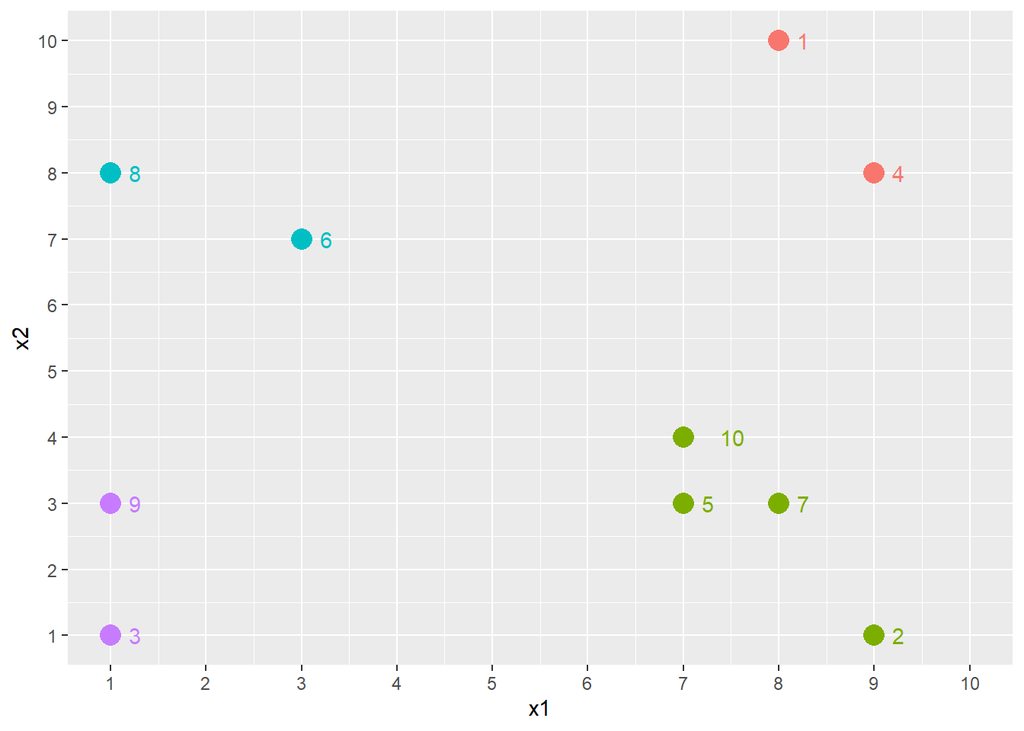

```r
data3 = cbind(data2,kmc=km$cluster)
ggplot(data=data3,aes(x=x1,y=x2,color=factor(kmc)))+
  geom_point(aes(size=1.2))+
  scale_x_continuous(limits=c(1,10),breaks=1:10)+
  scale_y_continuous(limits=c(1,10),breaks=1:10)+
  guides(size=F,color=F)+
  geom_text(aes(label=rownames(data3)),hjust=-1.5,vjust=0.5)
```

## Model-Based Clustering

Key idea of model-based clustering is that Observations come from groups with different statistical distributions (such as different means and variances). The algorithms try to find the best set of such underlying distributions to explain the observed data.

```r
library(mclust)
clus = Mclust(data)
summary(clus)
```

```
## ----------------------------------------------------
## Gaussian finite mixture model fitted by EM algorithm
## ----------------------------------------------------
##
## Mclust EII (spherical, equal volume) model with 9 components:
##
##  log-likelihood  n df       BIC       ICL
##       -13.12953 10 27 -88.42886 -88.42886
##
## Clustering table:
## 1 2 3 4 5 6 7 8 9
## 1 1 1 1 2 1 1 1 1
```

Model-based clustering Infers ideal number of clusters by comparing a variety of different mixture shapes.

But, one could also specify the number of clusters. Quality of a cluster solution is inferred from log-likelihood and BIC

```r
clus4 = Mclust(data,G = 4)
summary(clus4)
```

```
## ----------------------------------------------------
## Gaussian finite mixture model fitted by EM algorithm
## ----------------------------------------------------
##
## Mclust EEV (ellipsoidal, equal volume and shape) model with 4 components:
##
##  log-likelihood  n df       BIC       ICL
##       -26.66904 10 17 -92.48203 -92.48204
##
## Clustering table:
## 1 2 3 4
## 2 4 2 2
```

One could also compare BIC for a set of clustering solutions as above. Note, Mclust() generates negative of bic, so the sign has been flipped.

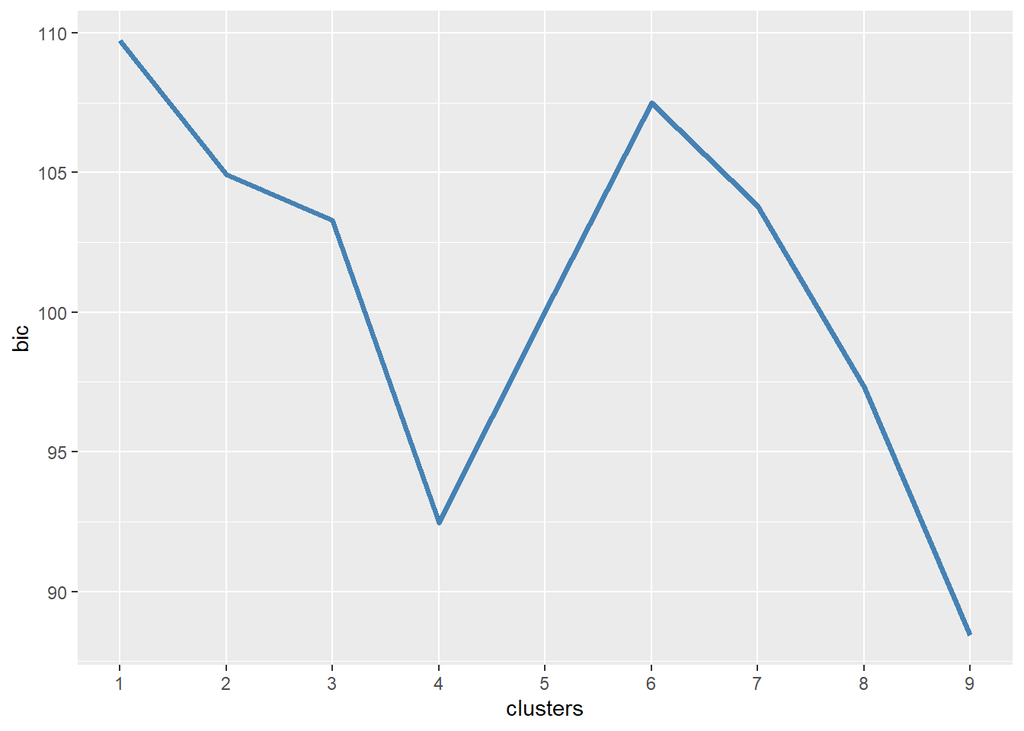

```r
bic = sapply(1:9,FUN=function(x){
  -Mclust(data,G=x)$bic
})
dat = data.frame(clusters=1:9,bic)
ggplot(dat,aes(x=clusters,y=bic))+
  geom_line(color='steelblue',size=1.4)+
  scale_x_continuous(breaks=1:9,minor_breaks = 1:9)
```

Let us extract cluster memberships for a four cluster solution

```r
mcluster = Mclust(data,G=4)
```

Finally, we can visualize the solution

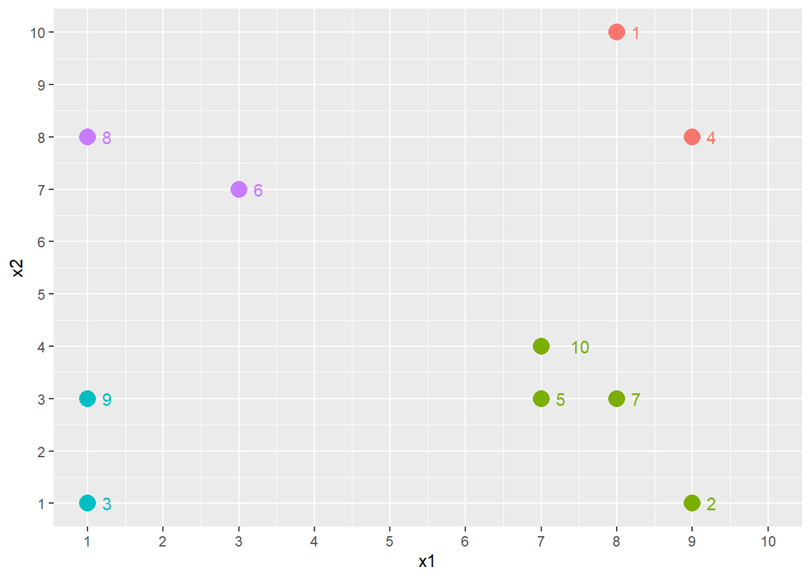

```r
data4 = cbind(data3,mclust=mcluster$classification)
ggplot(data=data4,aes(x=x1,y=x2,color=factor(mclust)))+
  geom_point(aes(size=1.2))+
  scale_x_continuous(limits=c(1,10),breaks=1:10)+
  scale_y_continuous(limits=c(1,10),breaks=1:10)+
  guides(size=F,color=F)+
  geom_text(aes(label=rownames(data3)),hjust=-1.5,vjust=0.5)
```

This file was generated using R Version 4.1.2